**Module 5 PROJECT REPORT**  
Probability Theory and Introductory Statistics, CRN: 70487  
Student: vaidehi Patole  
Instructor: Dee Chiluiza Reyes  
12/04/2021

**Linear Regression**

**INTRODUCTION**

**Correlation:**  
Correlation is a statistical measure that expresses the degree to which two variables are linearly connected (meaning they change together at a constant rate). It’s a typical approach for describing simple relationships without stating cause and effect. Correlations are useful for describing simple data correlations. Consider the following scenario: you are looking at a dataset of campsites in a mountain park. You’re curious if there’s a link between the elevation of the campsite (how high up the mountain it is) and the typical high temperature in the summer. You have two measurements for each campsite: height and temperature. When you use a correlation to examine these two variables across your sample, you can establish a linear relationship: as elevation increases, temperature decreases. They are inversely connected.

**Simple linear regression:**  
To evaluate the association between two quantitative variables, simple linear regression is performed. You can use simple linear regression when you want to know:

1. The strength of the link between two variables (e.g. the relationship between rainfall and soil erosion).
2. At a given value of the independent variable, the value of the dependent variable (e.g. the amount of soil erosion at a certain level of rainfall).

Example You are a social scientist who is interested in the connection between income and happiness. You poll 500 people with earnings ranging from $15k to $75k and ask them to rate their level of happiness on a scale of 1 to 10. Because your independent variable (income) and dependent variable (happiness) are both quantitative, you can perform a regression analysis to check if they have a linear connection.

**History:**  
Francis Galton invented correlation in late 1888, when he noticed a common thread in three different scientific topics he was examining. Karl Pearson’s widely known linkage of correlation with a retreat into a recess at Naworth Castle is addressed and contrasted with Galton’s own 1890 version of the time of discovery. The events that prompted Galton to write the account are discussed.

**Practical Application In Industry:**  
Correlation is frequently used in portfolio management (Portfolio management is the art and science of selecting and overseeing a group of investments that meet the long-term financial objectives and risk tolerance of a client, a company, or an institution) to assess the degree of diversification among the assets in a portfolio. To help establish the most optimal frontier, modern portfolio theory (MPT) (The modern portfolio theory (MPT) is a practical method for selecting investments in order to maximize their overall returns within an acceptable level of risk) employs a measure of the correlation of all the assets in a portfolio. This notion aids in the optimization of expected returns versus a given amount of risk. Including assets with low correlation to one another helps to lower overall risk in a portfolio. Nonetheless, correlation can shift over time. It can only be measured in the past. Two assets that have previously had a high degree of connection can become uncorrelated and begin to move independently. This is one of MPT’s flaws; it presupposes constant relationships between assets.

```r
library("readxl")
library("dplyr")
library("readr")
library("knitr")
library("kableExtra")
library("tidyverse")
library("vcd")
library("lessR")
library("RColorBrewer")
library("ggplot2")
```

**Task 1**

Understanding the dataset by exploratory analysis of data:

```r
str(mpg)
```

```
## tibble [234 x 11] (S3: tbl_df/tbl/data.frame)
##  $ manufacturer: chr [1:234] "audi" "audi" "audi" "audi" ...
##  $ model       : chr [1:234] "a4" "a4" "a4" "a4" ...
##  $ displ       : num [1:234] 1.8 1.8 2 2 2.8 2.8 3.1 1.8 1.8 2 ...
##  $ year        : int [1:234] 1999 1999 2008 2008 1999 1999 2008 1999 1999 2008 ...
##  $ cyl         : int [1:234] 4 4 4 4 6 6 6 4 4 4 ...
##  $ trans       : chr [1:234] "auto(l5)" "manual(m5)" "manual(m6)" "auto(av)" ...
##  $ drv         : chr [1:234] "f" "f" "f" "f" ...
##  $ cty         : int [1:234] 18 21 20 21 16 18 18 18 16 20 ...
##  $ hwy         : int [1:234] 29 29 31 30 26 26 27 26 25 28 ...
##  $ fl          : chr [1:234] "p" "p" "p" "p" ...
##  $ class       : chr [1:234] "compact" "compact" "compact" "compact" ...
```

```r
manufacturer = table(mpg$manufacturer)
model = table(mpg$model)
trans  = table(mpg$trans)
drv = table(mpg$drv)
fl = table(mpg$fl)
class = table(mpg$class)


print(paste("Analysis of the Categorial manufacturer : "))
```

```
## [1] "Analysis of the Categorial manufacturer : "
```

```r
manufacturer
```

```
##
##       audi  chevrolet      dodge       ford      honda    hyundai       jeep
##         18         19         37         25          9         14          8
## land rover    lincoln    mercury     nissan    pontiac     subaru     toyota
##          4          3          4         13          5         14         34
## volkswagen
##         27
```

```r
print(paste("Analysis of the Categorial model : "))
```

```
## [1] "Analysis of the Categorial model : "
```

```r
model
```

```
##
##            4runner 4wd                     a4             a4 quattro
##                      6                      7                      8
##             a6 quattro                 altima     c1500 suburban 2wd
##                      3                      6                      5
##                  camry           camry solara            caravan 2wd
##                      7                      7                     11
##                  civic                corolla               corvette
##                      9                      5                      5
##      dakota pickup 4wd            durango 4wd         expedition 2wd
##                      9                      7                      3
##           explorer 4wd        f150 pickup 4wd           forester awd
##                      6                      7                      6
##     grand cherokee 4wd             grand prix                    gti
##                      8                      5                      5
##            impreza awd                  jetta        k1500 tahoe 4wd
##                      8                      9                      4
## land cruiser wagon 4wd                 malibu                 maxima
##                      2                      5                      3
##        mountaineer 4wd                mustang          navigator 2wd
##                      4                      9                      3
##             new beetle                 passat         pathfinder 4wd
##                      6                      7                      4
##    ram 1500 pickup 4wd            range rover                 sonata
##                     10                      4                      7
##                tiburon      toyota tacoma 4wd
##                      7                      7
```

```r
print(paste("Analysis of the Categorial transmission : "))
```

```
## [1] "Analysis of the Categorial transmission : "
```

```r
trans
```

```
##
##   auto(av)   auto(l3)   auto(l4)   auto(l5)   auto(l6)   auto(s4)   auto(s5)
##          5          2         83         39          6          3          3
##   auto(s6) manual(m5) manual(m6)
##         16         58         19
```

```r
print(paste("Analaysis of the categorical variable -drivevtrain"))
```

```
## [1] "Analaysis of the categorical variable -drivevtrain"
```

```r
drv
```

```
##
##   4   f   r
## 103 106  25
```

```r
print(paste("Analysis of the categorical variable -fuel type-"))
```

```
## [1] "Analysis of the categorical variable -fuel type-"
```

```r
fl
```

```
##
##   c   d   e   p   r
##   1   5   8  52 168
```

```r
print(paste("Analysis of categorical variable  -class-"))
```

```
## [1] "Analysis of categorical variable  -class-"
```

```r
class
```

```
##
##    2seater    compact    midsize    minivan     pickup subcompact        suv
##          5         47         41         11         33         35         62
```

**Observation**

From the above code snippet and output, we can come to conclusion that this data is related to cars. More over variables HWY, FL, CTY hints that data about analyzing the mileage of data. Therefore We can assume that the dataset can be used to estimate the fuel economy of cars and presence of year variable and car manufacturer and model type variables we can add further that fuel economy of the cars across different maufacturers and models across a time period is analysed . To confirm we will check online dataset repository and finalize the dataset.

**Task 1.2**

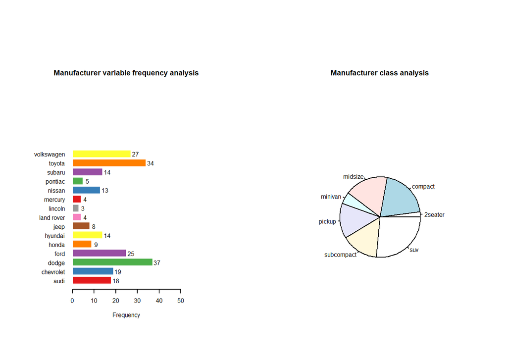

```r
par(mfrow=c(1,2) )
par(cex=0.5, mai=c(1,1,2,1))
y= barplot(manufacturer,horiz = TRUE,las =1,
        main="Manufacturer variable frequency analysis",
        xlab="Frequency",col=brewer.pal(9,"Set1"),border="white",
xlim=c(0,50))
text(manufacturer+2 ,y,labels = as.character(manufacturer),las =1)

class = table(mpg$class)

pie(class, main = "Manufacturer class analysis")
```

**Observation**

**Task 1.3**

```r
coefficient_of_correlation = cor(mpg$displ ,mpg$cyl)

print(paste("The coefficients of correlation between displacement and cylinders is ",coefficient_of_correlation))
```

```
## [1] "The coefficients of correlation between displacement and cylinders is  0.93022710241985"
```

```r
displacement = mpg$displ
cylinders =  mpg$cyl
linear_model = lm(displacement~cylinders)

coefficient_of_determination = summary(linear_model)$r.squared

print(paste("The coefficients of correlation between displacement and cylinders is ",coefficient_of_determination))
```

```
## [1] "The coefficients of correlation between displacement and cylinders is  0.86532246207643"
```

**Observation**  
The correlation coefficient is a statistical measure of the strength of the association between two variables’ relative movements. The values range from -1.0 to 1.0. A computed value greater than 1.0 or less than -1.0 indicates that the correlation measurement was incorrect. A correlation of -1.0 indicates that there is a perfect negative connection, whereas a correlation of 1.0 indicates that there is a perfect positive correlation. A correlation of 0.0 indicates that there is no linear link between the two variables’ movements.

The correlation coefficientin this scenario suggests a strong relationship between displacement and cylinders of the car. There may be a direct cause-and-effect relationship between the variables.

The R2 score, also known as the coefficient of determination, is used to evaluate the efficacy of a linear regression model. The amount of variance in the output dependent characteristic that can be predicted based on the input independent variable (s). It’s used to examine how effectively the model reproduces observed findings, based on the ratio of total deviation of results explained by the model.

In this current scenario, R2 = 0.865 ;86 percent ofthevariation of displacement isduetothe variation of cylinders; 14% is due to chance

```r
library("DescTools")
```

**Task 1 .5**

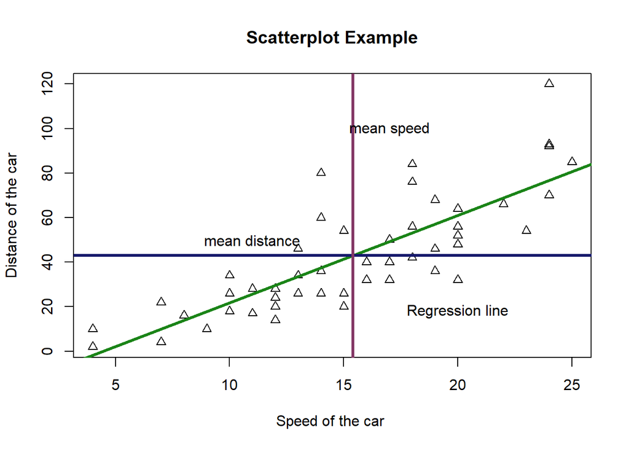

```r
plot(cars$speed, cars$dist, main="Scatterplot Example",
   xlab="Speed of the car ", ylab="Distance of the car", pch=2)

abline(lm(cars$dist~ cars$speed), col="#1A8417",lwd = 3) # regression line (y~x)
text( 20, 18, "Regression line")
abline(h = mean(cars$dist), col = "#16196C", lwd = 3, lty=1)
text( 11 , 50, "mean distance")
abline(v = mean(cars$speed), col = "#843765", lwd = 3, lty=1  )
text( 17 ,100 , "mean speed")
```

**Task 1.6**

```r
#distance = a+Speed ∗b

linearmodel_distance = lm(cars$dist~cars$speed) #the linear regression
summary(linearmodel_distance)
```

```
##
## Call:
## lm(formula = cars$dist ~ cars$speed)
##
## Residuals:
##     Min      1Q  Median      3Q     Max
## -29.069  -9.525  -2.272   9.215  43.201
##
## Coefficients:
##             Estimate Std. Error t value         Pr(>|t|)
## (Intercept) -17.5791     6.7584  -2.601           0.0123 *
## cars$speed    3.9324     0.4155   9.464 0.00000000000149 ***
## ---
## Signif. codes:  0 '***' 0.001 '**' 0.01 '*' 0.05 '.' 0.1 ' ' 1
##
## Residual standard error: 15.38 on 48 degrees of freedom
## Multiple R-squared:  0.6511, Adjusted R-squared:  0.6438
## F-statistic: 89.57 on 1 and 48 DF,  p-value: 0.00000000000149
```

```r
#distance = a+Speed ∗b

distance_for_30mph = (-17.5791) + 30 * (3.9324)

print(paste(" The stopping distance for vechile driving at 30 miles per hour is ", distance_for_30mph))
```

```
## [1] " The stopping distance for vechile driving at 30 miles per hour is  100.3929"
```

**Task 2.2**

```r
V_Shaped = sum( mtcars$vs == 0)

#V_Shaped

Straight_engine = sum(mtcars$vs == 1)

#Straight_engine


Total = length(mtcars$vs)

V_shapedpercent  = (V_Shaped/length(mtcars$vs))*100

Straight_enginepercent = (Straight_engine/length(mtcars$vs))*100

engine = matrix(c(V_Shaped,Straight_engine,Total,V_shapedpercent,Straight_enginepercent,100),byrow = TRUE,nrow =2)
rownames(engine) = c("Frequencies", "Percentages")
colnames(engine) =  c("V Shaped", "Straight Engine", "Total")

knitr::kable(engine, caption = "Frequency of cars with V-shaped versus Straight engines",full_width = T)%>%kable_styling()%>%
 kable_material(c("striped", "hover"))
```

Frequency of cars with V-shaped versus Straight engines

|  | V Shaped | Straight Engine | Total |
| --- | --- | --- | --- |
| Frequencies | 18.00 | 14.00 | 32 |
| Percentages | 56.25 | 43.75 | 100 |

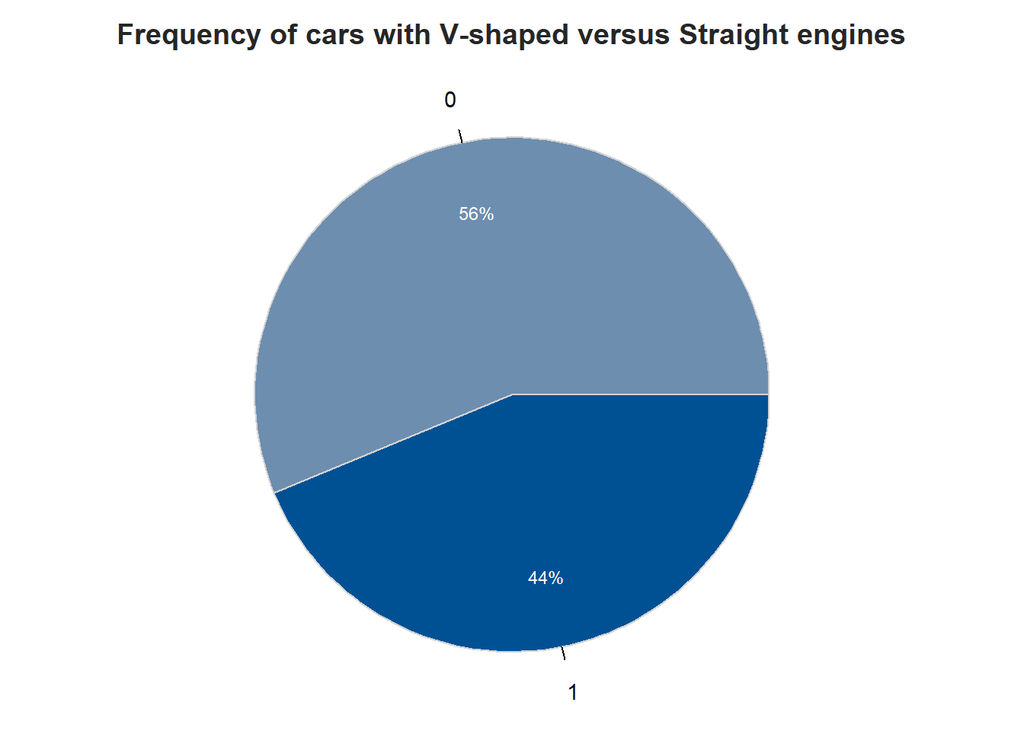

```
## >>> Suggestions
## PieChart(engines, hole=0)  # traditional pie chart
## PieChart(engines, values="%")  # display %'s on the chart
## BarChart(engines)  # bar chart
## Plot(engines)  # bubble plot
## Plot(engines, values="count")  # lollipop plot
##
##
## --- engines ---
##
##
##                    0      1    Total
## Frequencies:      18     14       32
## Proportions:   0.562  0.438    1.000
##
##
## Chi-squared test of null hypothesis of equal probabilities
##   Chisq = 0.500, df = 1, p-value = 0.480
```

```r
engines = mtcars$vs

PieChart(engines, hole = 0, values = "%", main = "Frequency of cars with V-shaped versus Straight engines")
```

**Observation**  
From the above table we can see that Vshaped engines are higher than straight engines. There are total 32 cars out of that 18 are Vshaped and 14 are straight engine. the data is collected properly since the both the classes are approximately equal

**Task 2.4**

```r
coefficient_of_correlation = cor(mtcars$mpg ,mtcars$wt)

print(paste("The coefficients of correlation between mileage  and weight is ",coefficient_of_correlation))
```

```
## [1] "The coefficients of correlation between mileage  and weight is  -0.867659376517228"
```

```r
linear_model = lm(mtcars$mpg~mtcars$wt)

coefficient_of_determination = summary(linear_model)$r.squared

print(paste("The coefficients of correlation between mileage and weight is ",coefficient_of_determination))
```

```
## [1] "The coefficients of correlation between mileage and weight is  0.752832793658264"
```

**Observation**

In this weight is independant and miles per gallon is dependant

The correlation coefficient is a statistical measure of the strength of the association between two variables’ relative movements. The values range from -1.0 to 1.0. A computed value greater than 1.0 or less than -1.0 indicates that the correlation measurement was incorrect. A correlation of -1.0 indicates that there is a perfect negative connection, whereas a correlation of 1.0 indicates that there is a perfect positive correlation. A correlation of 0.0 indicates that there is no linear link between the two variables’ movements.

The correlation coefficientin this scenario suggests a strong negative relationship between miles per gallon and weight of the car. There may be a direct cause-and-effect relationship between the variables.

The R2 score, also known as the coefficient of determination, is used to evaluate the efficacy of a linear regression model. The amount of variance in the output dependent characteristic that can be predicted based on the input independent variable (s). It’s used to examine how effectively the model reproduces observed findings, based on the ratio of total deviation of results explained by the model.

In this current scenario, R2 = 0.75 ;75 percent of thevariation of miles per gallon is due to the variation of weights; 25% is due to chance

**Task 2.5**

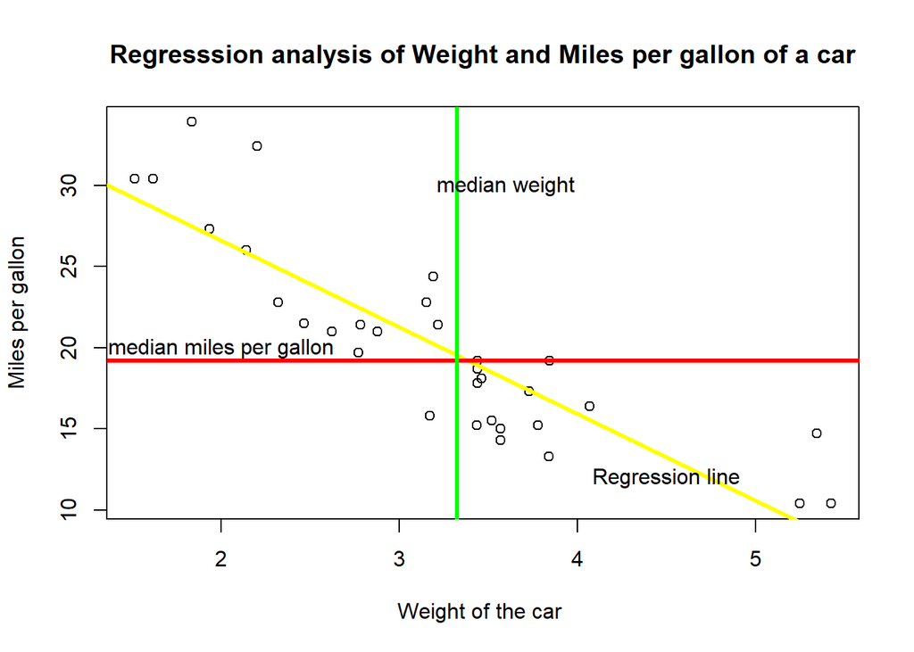

```r
plot(mtcars$wt, mtcars$mpg, main="Regresssion analysis of Weight and Miles per gallon of a car",
   xlab="Weight of the car ", ylab="Miles per gallon")

val = lm(mtcars$mpg ~ mtcars$wt)
abline(val, col="yellow",lwd = 3)
text( 4.5, 12, "Regression line")
abline(h = median(mtcars$mpg), col = "red", lwd = 3, lty=1)
text( 2,20,  "median miles per gallon")
abline(v = median(mtcars$wt), col = "green", lwd = 3, lty=1  )
text( 3.6 ,30, "median weight")
```

**Task 2.5**

```r
linearmodel_miles_per_gallon = lm(mtcars$mpg~mtcars$wt) #the linear regression
summary(linearmodel_miles_per_gallon)
```

```
##
## Call:
## lm(formula = mtcars$mpg ~ mtcars$wt)
##
## Residuals:
##     Min      1Q  Median      3Q     Max
## -4.5432 -2.3647 -0.1252  1.4096  6.8727
##
## Coefficients:
##             Estimate Std. Error t value             Pr(>|t|)
## (Intercept)  37.2851     1.8776  19.858 < 0.0000000000000002 ***
## mtcars$wt    -5.3445     0.5591  -9.559       0.000000000129 ***
## ---
## Signif. codes:  0 '***' 0.001 '**' 0.01 '*' 0.05 '.' 0.1 ' ' 1
##
## Residual standard error: 3.046 on 30 degrees of freedom
## Multiple R-squared:  0.7528, Adjusted R-squared:  0.7446
## F-statistic: 91.38 on 1 and 30 DF,  p-value: 0.0000000001294
```

```r
#miles per gallon  = a+Weight ∗b

miles_for_2000pounds = (37.2851) + (-5.3445) *(2000)

print(paste(" The miles per gallon for a car with wieght 2000 pounds   is ", miles_for_2000pounds))
```

```
## [1] " The miles per gallon for a car with wieght 2000 pounds   is  -10651.7149"
```

**Conclusion**

However, no one test can accurately forecast fuel efficiency for all drivers in all conditions. The following things, for example, can reduce your vehicle’s fuel economy: • Excessive idling, accelerating, and braking in stop-and-go traffic • Excessive idling, accelerating, and braking in cold weather (engines are more efficient when warmed up). Short travels have a stronger influence. • Driving with a heavy load or with the air conditioner on • Improperly tuned engine or under-inflated tires • Driving in rocky or hilly terrain • Using high-performance or snow tires • Using remote starters

Eventhough there is correlation between two variables, further we need to check if the both are able to contribute towards expected output or they are jus lurking variables.

**References**

Stephen M. Stigler. “Francis Galton’s Account of the Invention of Correlation.” Statist. Sci. 4 (2) 73 - 79, May, 1989. https://doi.org/10.1214/ss/1177012580

Investopedia. Correlation Coefficient by Jason Fernando on October 05,2021 . Retrieved on December 11,2021 https://www.investopedia.com/terms/c/correlationcoefficient.asp

Statistical Discovery (n.d) . Retrieved on December 11,2021https://www.jmp.com/en_us/statistics-knowledge-portal/what-is-correlation.html